# TP Analyse de Données de Fiabilité

Author

Theau Aguet

Published

March 6, 2026

**Voir le code R**

```r
library(survival)
library(fitdistrplus)
```

# 1 EXERCICE 1.1 : Pompes hydrauliques

## 1.1 Valeurs ordonnées $t_{(i)}$

Après tri des 50 données par ordre croissant :

- $t_{(1)} = 23.774$
- $t_{(5)} = 122.750$
- $t_{(10)} = 175.578$
- $t_{(50)} = 1032.227$

## 1.2 Estimation de la fiabilité $\hat{R}(t)$

On utilise l’estimateur des rangs $\hat{R}(t_{(i)}) = \frac{n-i}{n}$ :

- $\hat{R}(t_{(1)}) = 49/50 = 0.98$
- $\hat{R}(t_{(5)}) = 45/50 = 0.90$
- $\hat{R}(t_{(10)}) = 40/50 = 0.80$
- $\hat{R}(t_{(50)}) = 0/50 = 0$

## 1.3 Intervalle de confiance à 95%

Formule :

$$\hat{R} \pm 1.96 \sqrt{\frac{\hat{R}(1-\hat{R})}{n}}$$

## 1.4 Censure à 500h

L’instant $t_{(10)} = 175.578$ est inférieur à 500. Aucune censure n’est intervenue avant ce point. L’estimateur de Kaplan-Meier donne $\hat{R}_{KM}(t_{(10)}) = 0.80$. La valeur est identique car la censure n’impacte que les calculs pour $t > 500$.

**Voir le code R**

```r
# Chargement et tri
data_pompe <- read.csv("../data/td_1/pompehydro.csv")
t_sorted <- sort(data_pompe$Temps)
n <- length(t_sorted)

# Fiabilité empirique et IC
R_hat <- (n - 1:n) / n
indices <- c(1, 5, 10, 50)
ic_95 <- 1.96 * sqrt((R_hat * (1 - R_hat)) / n)

# Affichage des résultats
res1.1 <- data.frame(t_i = t_sorted[indices], R_hat = R_hat[indices],
                     LB = pmax(0, R_hat[indices] - ic_95[indices]),
                     UB = pmin(1, R_hat[indices] + ic_95[indices]))
print(res1.1)
```

```
       t_i R_hat        LB        UB
1   23.774  0.98 0.9411940 1.0000000
2  122.750  0.90 0.8168442 0.9831558
3  175.578  0.80 0.6891257 0.9108743
4 1032.227  0.00 0.0000000 0.0000000
```

**Voir le code R**

```r
# Kaplan-Meier avec censure à 500h
status <- ifelse(t_sorted <= 500, 1, 0)
times_c <- pmin(t_sorted, 500)
km_fit <- survfit(Surv(times_c, status) ~ 1)
summary(km_fit, times = t_sorted[10])
```

```
Call: survfit(formula = Surv(times_c, status) ~ 1)

 time n.risk n.event survival std.err lower 95% CI upper 95% CI
  176     41      10      0.8  0.0566        0.696        0.919
```

# 2 EXERCICE 1.2 : Épicerie

L’estimateur approprié est celui de **Kaplan-Meier**. Il permet de traiter les données “censurées” (produits retirés car périmés avant d’être achetés). On calcule la survie à chaque instant $t_i$ où un achat (A) a lieu :

$$S(t_i) = S(t_{i-1}) \times \left(1 - \frac{d_i}{n_i}\right)$$

Où $d_i$ est le nombre d’achats à $t_i$ et $n_i$ le nombre de produits encore en rayon juste avant $t_i$.

**Voir le code R**

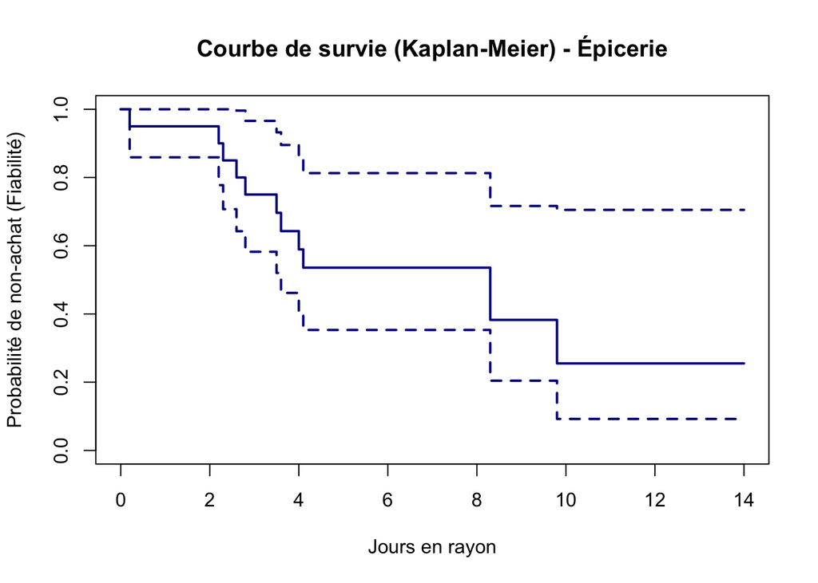

```r
# Utiliser read.csv2 ou spécifier dec = "," pour les fichiers européens
data_epi <- read.csv("../data/td_1/epicerie.csv", dec = ",", check.names = TRUE)

# On vérifie les noms exacts générés par R
# (Probablement "temps.passé.en.rayon" et "produit.acheté")

# Création de l'indicateur d'événement
# Ici, produit.acheté == 0 signifie que l'événement "Achat" a eu lieu (donnée non censurée)
data_epi$event <- ifelse(data_epi$produit.acheté == 0, 1, 0)

# Création de l'objet de survie et du modèle de Kaplan-Meier
km_epi <- survfit(Surv(temps.passé.en.rayon, event) ~ 1, data = data_epi)

# Affichage du graphique
plot(km_epi,
     main="Courbe de survie (Kaplan-Meier) - Épicerie",
     xlab="Jours en rayon",
     ylab="Probabilité de non-achat (Fiabilité)",
     col="darkblue",
     lwd=2,
     conf.int=TRUE) # Ajoute les bandes de confiance, c'est plus pro !
```

# 3 EXERCICE 1.3 : Résistance chauffante

La distribution la plus pertinente est **Weibull**. Les données (autour de 1.8 mois avec peu de dispersion) suggèrent un phénomène d’usure. Une loi exponentielle impliquerait un taux de défaillance constant (hasard pur), ce qui est rare pour du matériel chauffant qui subit une dégradation thermique. Une loi de Weibull avec $\beta > 1$ modélisera mieux ce vieillissement.

**Voir le code R**

```r
durees <- c(1.806, 2.274, 1.925, 1.280, 1.993, 2.104, 1.822, 1.491, 1.680, 1.650)

# Comparaison des modèles
fit_w <- fitdist(durees, "weibull")
fit_e <- fitdist(durees, "exp")
gofstat(list(fit_w, fit_e))
```

```
Goodness-of-fit statistics
                             1-mle-weibull 2-mle-exp
Kolmogorov-Smirnov statistic     0.1086505 0.5084172
Cramer-von Mises statistic       0.0155379 0.7045433
Anderson-Darling statistic       0.1179199 3.3013204

Goodness-of-fit criteria
                               1-mle-weibull 2-mle-exp
Akaike's Information Criterion      6.738382  33.78349
Bayesian Information Criterion      7.343552  34.08608
```

# 4 EXERCICE 1.4 : Transistors

## 4.2 Expressions pour Weibull ($\alpha, \beta$)

La log-vraisemblance est :

$$L = n\ln\beta - n\beta\ln\alpha + (\beta-1)\sum\ln t_i - \sum\left(\frac{t_i}{\alpha}\right)^\beta$$

- $\hat{\alpha} = \left( \frac{1}{n} \sum_{i=1}^n t_i^{\hat{\beta}} \right)^{1/\hat{\beta}}$
- $\hat{\beta}$ est solution de : $\frac{1}{\hat{\beta}} + \frac{1}{n}\sum \ln t_i - \frac{\sum t_i^{\hat{\beta}} \ln t_i}{\sum t_i^{\hat{\beta}}} = 0$.

**Voir le code R**

```r
data_trans <- read.csv("../data/td_1/transistor.csv")

# 1. Estimation Exponentielle
lambda_hat <- 1 / mean(data_trans$TTF)
print(paste("Lambda chapeau :", lambda_hat))
```

```
[1] "Lambda chapeau : 4.04938631550389e-06"
```

**Voir le code R**

```r
# 2. Estimation Weibull
fit_wei_trans <- fitdist(data_trans$TTF, "weibull")
summary(fit_wei_trans)
```

```
Fitting of the distribution ' weibull ' by maximum likelihood
Parameters :
          estimate   Std. Error
shape 1.148247e+00    0.1364979
scale 2.590286e+05 7518.7492429
Loglikelihood:  -536.1006   AIC:  1076.201   BIC:  1079.579
Correlation matrix:
           shape      scale
shape 1.00000000 0.06469296
scale 0.06469296 1.00000000
```

# 5 EXERCICE 1.5 : Test statistique

## 5.1 Test et Région critique

On teste $H_0 : \lambda = \lambda_0 = 55 \times 10^{-5}$ contre $H_1 : \lambda > \lambda_0$. Sous $H_0$, le nombre de défaillances $K$ sur un temps total $T$ suit une loi de Poisson $\mathcal{P}(\lambda_0 T)$.

- Temps total $T = 4800$ heures.
- Espérance $E = \lambda_0 T = 2.64$.
- Région critique : Rejet de $H_0$ si $K \geq k_{crit}$ tel que $P(K \geq k_{crit} | H_0) \leq 0.05$.

## 5.2 Décision

On observe $K = 4$. Calcul de la p-valeur : $P(K \geq 4) \approx 0.27$. $0.27 > 0.05$, donc on ne rejette pas $H_0$. L’affirmation du fabricant est jugée légitime.

## 5.3 Erreur et Enseignement

Accepter un lot défectueux ($\lambda = 180 \times 10^{-5}$) est une **erreur de seconde espèce ($\beta$)**. Le test actuel a une puissance faible. Avec $\lambda = 180 \times 10^{-5}$, l’espérance est de $8.64$.

**Recommandation :** Augmenter la durée des tests ou le nombre de circuits testés.

**Voir le code R**

```r
lambda0 <- 55e-5
T_total <- 20 * 10 * 24
mu0 <- lambda0 * T_total

# Question 2 : p-valeur pour K=4
p_value <- 1 - ppois(3, mu0)
print(paste("P-valeur :", p_value))
```

```
[1] "P-valeur : 0.272727044772578"
```

**Voir le code R**

```r
# Question 3 : Calcul de beta (erreur type II) pour lambda = 180e-5
lambda1 <- 180e-5
mu1 <- lambda1 * T_total
k_crit <- qpois(0.95, mu0) + 1
beta_err <- ppois(k_crit - 1, mu1)
print(paste("Probabilité d'erreur beta :", beta_err))
```

```
[1] "Probabilité d'erreur beta : 0.24156350530897"
```